# ML3_10March24_ESA_QP-Copy1

### March 2024: END SEMESTER ASSESSMENT (ESA)

## M TECH DATA SCIENCE AND MACHINE LEARNING_ SEMESTER II

### UE20CS932 - MACHINE LEARNING - III

```python
import pandas as pd
import numpy as np
import matplotlib.pyplot as plt
import seaborn as sns
from sklearn.preprocessing import StandardScaler
from sklearn.decomposition import PCA
from sklearn.cluster import KMeans,AgglomerativeClustering,DBSCAN
from sklearn.metrics import silhouette_score
from scipy.cluster.hierarchy import linkage , dendrogram, fcluster,cophenet
#from sklearn.model_selection import train_test_split
from sklearn.ensemble import RandomForestClassifier
from sklearn.metrics import classification_report
from sklearn.decomposition import TruncatedSVD
from sklearn.discriminant_analysis import LinearDiscriminantAnalysis
from surprise import KNNWithMeans,SVDpp
from surprise import Dataset
from surprise import accuracy
from surprise import Reader
from surprise.model_selection import train_test_split,cross_validate
from mlxtend.frequent_patterns import apriori
from mlxtend.frequent_patterns import association_rules
from surprise import KNNBasic
import warnings
warnings.filterwarnings("ignore")
```

[output not shown]

Note:

Use Credit-Card-Dataset-for-Clustering.csv for all the clustering and dimensionality reduction questions.

Use Book_ratings.csv for popularity-driven recommendation system questions and collaborative recommendation engine.

Use Online Retail.csv for association rule mining using, apriori algorithm questions.

### problem statement: This case requires to develop a customer segmentation to define marketing strategy. The sample Dataset summarizes the usage behavior of about 8950 active credit card holders during the last 6 months. The file is at a customer level with 18 behavioral variables. ### Data Description -CUSTID : Identification of Credit Card holder (Categorical) -BALANCE : Balance amount left in their account to make purchases -BALANCEFREQUENCY : How frequently the Balance is updated, score between 0 and 1 (1 = frequently updated, 0 = not frequently updated) -PURCHASES : Amount of purchases made from account -ONEOFFPURCHASES : Maximum purchase amount done in one-go -INSTALLMENTSPURCHASES : Amount of purchase done in installment -CASHADVANCE : Cash in advance given by the user -PURCHASESFREQUENCY : How frequently the Purchases are being made, score between 0 and 1 (1 = frequently purchased, 0 = not frequently purchased) -ONEOFFPURCHASESFREQUENCY : How frequently Purchases are happening in one-go (1 = frequently purchased, 0 = not frequently purchased) -PURCHASESINSTALLMENTSFREQUENCY : How frequently purchases in installments are being done (1 = frequently done, 0 = not frequently done) -CASHADVANCEFREQUENCY : How frequently the cash in advance being paid -CASHADVANCETRX : Number of Transactions made with "Cash in Advanced" -PURCHASESTRX : Numbe of purchase transactions made -CREDITLIMIT : Limit of Credit Card for user -PAYMENTS : Amount of Payment done by user -MINIMUM_PAYMENTS : Minimum amount of payments made by user -PRCFULLPAYMENT : Percent of full payment paid by user -TENURE : Tenure of credit card service for user

## Section B(40 marks)

#### 2. (a). Perform EDAand pre-processing techniques (remove unnecessary variables, check the defects in the data) required for PCA and clustering. (10 marks) Print the top 5 Eigenvalues and Eigenvectors. (4 marks)

```python
# Load the dataset
credit_card_df = pd.read_csv("Credit-Card-Dataset-for-Clustering.csv")

# Convert non-numeric columns to numeric (handling missing values)
credit_card_df.replace("?", np.nan, inplace=True)
credit_card_df["CREDIT_LIMIT"] = pd.to_numeric(credit_card_df["CREDIT_LIMIT"], errors='coerce')
credit_card_df["MINIMUM_PAYMENTS"] = pd.to_numeric(credit_card_df["MINIMUM_PAYMENTS"], errors='coerce')

# Drop unnecessary columns - as its an unique identifier
credit_card_df.drop(columns=["CUST_ID"], inplace=True)

# Fill missing values with the median
credit_card_df.fillna(credit_card_df.median(), inplace=True)

# Standardizing the data
scaler = StandardScaler()
scaled_data = scaler.fit_transform(credit_card_df)

# Performing PCA
pca = PCA()
pca.fit(scaled_data)

# Extract top 5 Eigenvalues and Eigenvectors
eigenvalues = pca.explained_variance_[:5]
eigenvectors = pca.components_[:5]

# Print the results
print("Eigen Values:\n",eigenvalues)
print("\nEigen Vectors:\n",eigenvectors)
```

```
Eigen Values:
 [4.64112269 3.45372843 1.49840831 1.27166123 1.05832222]

Eigen Vectors:
 [[ 0.10173497  0.12049041  0.4115624   0.34633416  0.33676092 -0.02280988
   0.32123217  0.29449254  0.27449428 -0.08858206 -0.04813551  0.39059872
   0.21191634  0.26648154  0.06326867  0.13183285  0.0810856 ]
 [ 0.40381873  0.13134414  0.04002462  0.06191772 -0.01917539  0.43902651
  -0.19114801 -0.01856091 -0.17886875  0.43412117  0.41964355 -0.02016821
   0.23802849  0.25671565  0.16906581 -0.19006529 -0.00425524]
 [ 0.16163198  0.42299545 -0.25747423 -0.39089919  0.10926846  0.02312809
   0.37139443 -0.11556486  0.46957883  0.10470904  0.11034514  0.07592937
  -0.10068174 -0.27735866  0.23451664 -0.12647724  0.06798872]
 [ 0.27931641  0.15576173  0.04162083  0.08507909 -0.05791521 -0.25659565
  -0.19456427  0.03427937 -0.22528752 -0.26462842 -0.32838559 -0.0207944
   0.13153307 -0.11214809  0.39256028 -0.41957367  0.43754782]
 [-0.05102225  0.4768362  -0.02788702  0.16083881 -0.36140247 -0.09756007
   0.0996674   0.54033045 -0.17699607  0.14516024  0.08388357  0.03623688
  -0.08630258 -0.20085061 -0.41504541 -0.14336327  0.00183805]]
```

##### 2. (b).Find the optimal number of clusters for the K-means clustering model [Note: Use the PCs, which are explaining the 90% variance]. (6 marks)

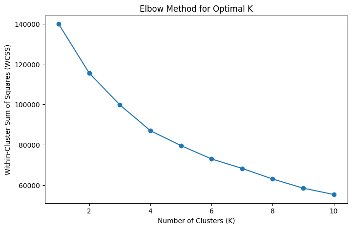

```
No. of Principal Components:  10
```

```python
# Compute the number of principal components explaining 90% variance
cumulative_variance = np.cumsum(pca.explained_variance_ratio_)
num_pcs = np.argmax(cumulative_variance >= 0.90) + 1  # Number of PCs explaining 90% variance

# Transform data using the selected PCs
pca_transformed_data = pca.transform(scaled_data)[:, :num_pcs]

# Using the Elbow Method to find the optimal K for K-Means
wcss = []  # Within-Cluster Sum of Squares
k_values = range(1, 11)  # Testing K values from 1 to 10

for k in k_values:
    kmeans = KMeans(n_clusters=k, random_state=42, n_init=10)
    kmeans.fit(pca_transformed_data)
    wcss.append(kmeans.inertia_)

# Plot the Elbow Curve
plt.figure(figsize=(8, 5))
plt.plot(k_values, wcss, marker='o', linestyle='-')
plt.xlabel('Number of Clusters (K)')
plt.ylabel('Within-Cluster Sum of Squares (WCSS)')
plt.title('Elbow Method for Optimal K')
plt.show()

# Return the number of principal components used
print("No. of Principal Components: ",num_pcs)
```

#### 2. (c). Plot the dendrograms using 4 linkage methods for the PCA transformed data and identify which one is the best. [Note: Use the PCs, which are explaining the 90% variance] (6 marks)

```python
#Hint:Use the following functions and create the dendrograms for 100 nodes only
# linkage(pca_df, method='single',metric='euclidean')
# dendrogram(mergings,truncate_mode='lastp',p=100)
```

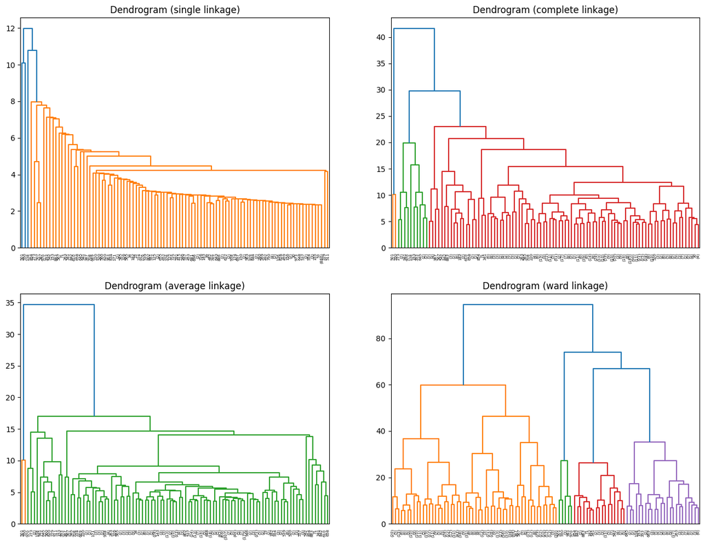

```python
import scipy.cluster.hierarchy as sch

# Subsampling for dendrogram (using only 100 samples for performance reasons)
sample_size = 1000
pca_sample = pca_transformed_data[:sample_size, :]

# Define linkage methods
linkage_methods = ['single', 'complete', 'average', 'ward']

# Plot dendrograms for different linkage methods (truncating to 100 nodes for readability)
plt.figure(figsize=(16, 12))
for i, method in enumerate(linkage_methods, 1):
    plt.subplot(2, 2, i)
    mergings = sch.linkage(pca_sample, method=method, metric='euclidean')
    sch.dendrogram(mergings, truncate_mode='lastp', p=100)
    plt.title(f'Dendrogram ({method} linkage)')

plt.show()
```

#### 2 (d)Cluster the data into 4 groups and order the cluster quality in terms of the inertia (WCSS) of each cluster. [Use ward linkage metric] (6 marks)

```python
# Reduce dataset size for hierarchical clustering
sample_size = 1000  # Using a smaller subset for hierarchical clustering
pca_sample = pca_transformed_data[:sample_size, :]

# Perform hierarchical clustering with Ward's linkage and 4 clusters
hierarchical_cluster = AgglomerativeClustering(n_clusters=4, linkage='ward')
cluster_labels = hierarchical_cluster.fit_predict(pca_sample)

# Compute Within-Cluster Sum of Squares (WCSS) for quality ranking
wcss_per_cluster = []
for cluster in range(4):
    cluster_points = pca_sample[cluster_labels == cluster]
    centroid = cluster_points.mean(axis=0)
    wcss = np.sum((cluster_points - centroid) ** 2)
    wcss_per_cluster.append((cluster, wcss))

# Sort clusters by increasing WCSS (lower WCSS is better)
sorted_clusters = sorted(wcss_per_cluster, key=lambda x: x[1])

# Return the sorted cluster quality ranking
print("Sorted Cluster:",sorted_clusters)
```

```
Sorted Cluster: [(2, 543.7695994018305), (3, 1416.1808881449247), (1, 2513.8914413454027), (0, 9446.769585285903)]
```

- Cluster 2 (Best) - WCSS = 543.77
- Cluster 3 - WCSS = 1416.18
- Cluster 1 - WCSS = 2513.89
- Cluster 0 (Worst) - WCSS = 9446.77

#### 2 (e)Compare the quality of clusters for K-means clustering algorithm on original data and PCA transformed data. (8 marks)

```python
from sklearn.metrics import silhouette_score

# Perform K-Means on original data
kmeans_original = KMeans(n_clusters=4, random_state=42, n_init=10)
labels_original = kmeans_original.fit_predict(scaled_data)
silhouette_original = silhouette_score(scaled_data, labels_original)

# Perform K-Means on PCA transformed data
kmeans_pca = KMeans(n_clusters=4, random_state=42, n_init=10)
labels_pca = kmeans_pca.fit_predict(pca_transformed_data)
silhouette_pca = silhouette_score(pca_transformed_data, labels_pca)

# Return Silhouette Scores for comparison
print("Silhouette Original",silhouette_original)
print("Silhouette PCA",silhouette_pca)
```

```
Silhouette Original 0.1976791965228765
Silhouette PCA 0.2169147222273636
```

As silhouette PCA > silhouette Original, PCA has improved clustering quality

##### Notes:

- If silhouette_pca > silhouette_original --> PCA has improved clustering quality
- If silhouette_pca < silhouette_original --> PCA removed useful information
- If silhouette_pca ≈ silhouette_original --> PCA did not significantly affect clustering quality

## Section C (40 marks)

#### 3 (a) Develop a popularity-driven recommendation system, print Total no of ratings,Total No of Users,Total No of products and recommend the top 5 items. (10 marks )

Use the dataset: Book_ratings.csv Variables: book_id - ID of the book. user_id - ID of the user rated ratings - ratings of the book by the user.

```python
# Load the dataset and display column names
book_ratings_df = pd.read_csv("Book_ratings.csv")
book_ratings_df.columns
```

```
Index(['Unnamed: 0.1', 'Unnamed: 0', 'book_id', 'user_id', 'rating'], dtype='object')
```

```python
# Compute total number of ratings, total users, and total books
total_ratings = book_ratings_df.shape[0]
total_users = book_ratings_df['user_id'].nunique()
total_books = book_ratings_df['book_id'].nunique()

# Aggregate ratings per book to find the most popular books
top_books = book_ratings_df.groupby("book_id")["rating"].count().reset_index()

# Sort in descending order to get the most popular books
top_books = top_books.sort_values(by="rating", ascending=False)

# Select the top 5 most rated books
top_5_books = top_books.head(5)

# Return computed values and recommended books
print("Total Ratings: ",total_ratings)
print("Total Users: ",total_users)
print("Total Books: ",total_books)
print("Top 5 Books: \n",top_5_books.to_string(index=False))
```

```
Total Ratings:  120000
Total Users:  7956
Total Books:  1201
Top 5 Books:
  book_id  rating
       1     100
     805     100
     803     100
     802     100
     801     100
```

#### 3 (b) Build collaborative recommendation engine. Use KNNBasic library with cosine similarity and measure the model quality by performing cross validation in terms of RMSE.

Use the dataset: Book_ratings.csv (20 Marks)

```python
# Load the dataset
# Create a Reader object
# Load the dataset into Surprise's Dataset format (Hint: Dataset.load_from_df(df[['user_id', 'book_id', 'rating']], reader))
```

```python
# Split the data into training and testing sets
# Build the collaborative filtering model (user-based in this case)
#Hint: sim_options = {'name': 'cosine', 'user_based': True}
#model = KNNBasic(sim_options=sim_options)
# Train the model
# Make predictions on the test set
# Calculate RMSE
```

```python
# Perform cross-validation


# Print the average RMSE across folds
```

```python
# pip install surprise
```

[output not shown]

[output not shown]

[output cut: 68 more lines]

[output not shown]

#### 3 (c) Create association rule mining using apriori algorithm.Perform basic pre-processing operations required by algorithm ( drop missing values, drop unnecessary columns). (7 marks) Create the basket only for France. Run algorithm with minimum support 0.07, tune with lift. (3 marks)

Use Dataset:Online Retail.csv

```python
#Read the data
#Check missing values
```

```python
#Hint : use the function to get frequesnt Itemsets
#apriori(basket for France, min_support, use_colnames=True)
#rules = association_rules(frequent_itemsets, metric="lift")
```